# 合租模式下的租房价格分析

葛宇泽 19307130176

2021/10/5

### 1.数据读入与汇总统计

```r
setwd("F:\\2021秋季\\机器学习\\HW3")
data <- read.csv("data.csv",header=T,fileEncoding = "UTF-8")
```

对数据进行汇总统计

```r
summary(data)
```

```
##       rent         bedroom        livingroom      bathroom          area
##  Min.   :1150   Min.   :2.000   Min.   :1.00   Min.   :1.000   Min.   : 5.00
##  1st Qu.:2240   1st Qu.:2.000   1st Qu.:1.00   1st Qu.:1.000   1st Qu.:10.00
##  Median :2690   Median :3.000   Median :1.00   Median :1.000   Median :12.00
##  Mean   :2798   Mean   :2.996   Mean   :1.01   Mean   :1.027   Mean   :12.85
##  3rd Qu.:3230   3rd Qu.:4.000   3rd Qu.:1.00   3rd Qu.:1.000   3rd Qu.:15.00
##  Max.   :6460   Max.   :5.000   Max.   :2.00   Max.   :2.000   Max.   :30.00
##
##    room       floor_grp    subway        region         heating
##  次卧:2860   低楼层:1679   否: 815   朝阳   :1317   集中供暖:4197
##  主卧:2289   高楼层:1592   是:4334   通州   : 819   自采暖  : 952
##              中楼层:1878             昌平   : 702
##                                      丰台   : 581
##                                      海淀   : 424
##                                      大兴   : 361
##                                      (Other): 945
```

整理得到如下

```r
library(knitr)
kable(summary(data))
```

|  | rent | bedroom | livingroom | bathroom | area | room | floor_grp | subway | region | heating |
| --- | --- | --- | --- | --- | --- | --- | --- | --- | --- | --- |
|  | Min. :1150 | Min. :2.000 | Min. :1.00 | Min. :1.000 | Min. : 5.00 | 次卧:2860 | 低楼层:1679 | 否: 815 | 朝阳 :1317 | 集中供暖:4197 |
|  | 1st Qu.:2240 | 1st Qu.:2.000 | 1st Qu.:1.00 | 1st Qu.:1.000 | 1st Qu.:10.00 | 主卧:2289 | 高楼层:1592 | 是:4334 | 通州 : 819 | 自采暖 : 952 |
|  | Median :2690 | Median :3.000 | Median :1.00 | Median :1.000 | Median :12.00 | NA | 中楼层:1878 | NA | 昌平 : 702 | NA |
|  | Mean :2798 | Mean :2.996 | Mean :1.01 | Mean :1.027 | Mean :12.85 | NA | NA | NA | 丰台 : 581 | NA |
|  | 3rd Qu.:3230 | 3rd Qu.:4.000 | 3rd Qu.:1.00 | 3rd Qu.:1.000 | 3rd Qu.:15.00 | NA | NA | NA | 海淀 : 424 | NA |
|  | Max. :6460 | Max. :5.000 | Max. :2.00 | Max. :2.000 | Max. :30.00 | NA | NA | NA | 大兴 : 361 | NA |
|  | NA | NA | NA | NA | NA | NA | NA | NA | (Other): 945 | NA |

### 2.绘制总体数据中月租金（rent）的直方图

总体数据月租金直方图如下：

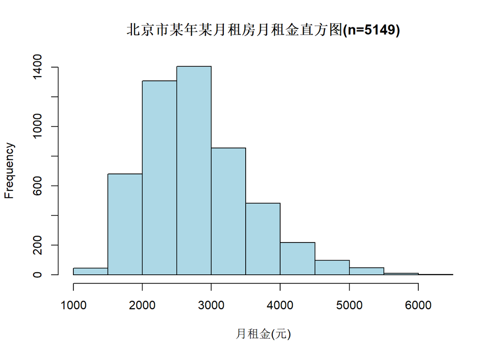

```r
hist(data$rent,,col="light blue",main = "北京市某年某月租房月租金直方图(n=5149)",xlab = "月租金(元)")
```

直方图呈右偏分布。月租金大多在2000-3000元之间，最低不低于1000元，最高不超过6500元。

### 3.计算不同城区(region)租房平均价格，选取平均租金最高的 8 个城区，绘制降序平均租金柱状图

城区平均月租金由大到小排序如下：

```r
aver_rent <- sort(tapply(data$rent,data$region,mean),decreasing = TRUE)
kable(aver_rent)
```

|  | x |
| --- | --- |
| 西城 | 3784.792 |
| 海淀 | 3490.920 |
| 朝阳 | 3302.103 |
| 东城 | 3262.872 |
| 石景山 | 2819.845 |
| 丰台 | 2734.286 |
| 昌平 | 2693.376 |
| 通州 | 2327.216 |
| 大兴 | 2241.136 |
| 顺义 | 2111.497 |
| 房山 | 1751.257 |

降序平均租金柱状图如下：

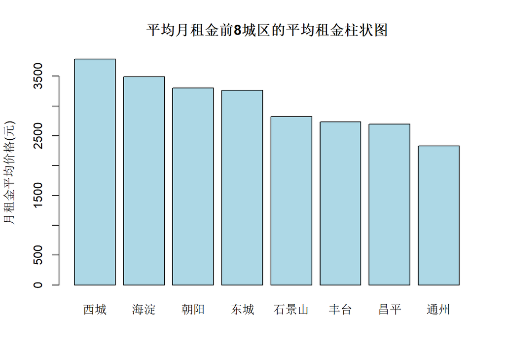

```r
barplot(aver_rent[1:8],ylab = "月租金平均价格(元)",main = "平均月租金前8城区的平均租金柱状图",col="light blue")
```

平均月租金最高的8个城区分别为西城、海淀、朝阳、东城、石景山、丰台、昌平、通州。

其中，西城区平均月租金最高，近4000元。通州平均月租金最低，近2500元。

海淀、朝阳、东城平均月租金相近，在3000-3500元之间；石景山、丰台、昌平平均月租金相近，在2500-3000元之间。

西城、海淀、朝阳、东城平均月租金均超过3000元，是寸土寸金的区域。海淀、大兴的样本量较少，不超过500，平均月租金可能存在更大的偏差。

### 4.绘制月租金（rent）-城区（region）分组箱线图

月租金-城区分组箱线图如下：

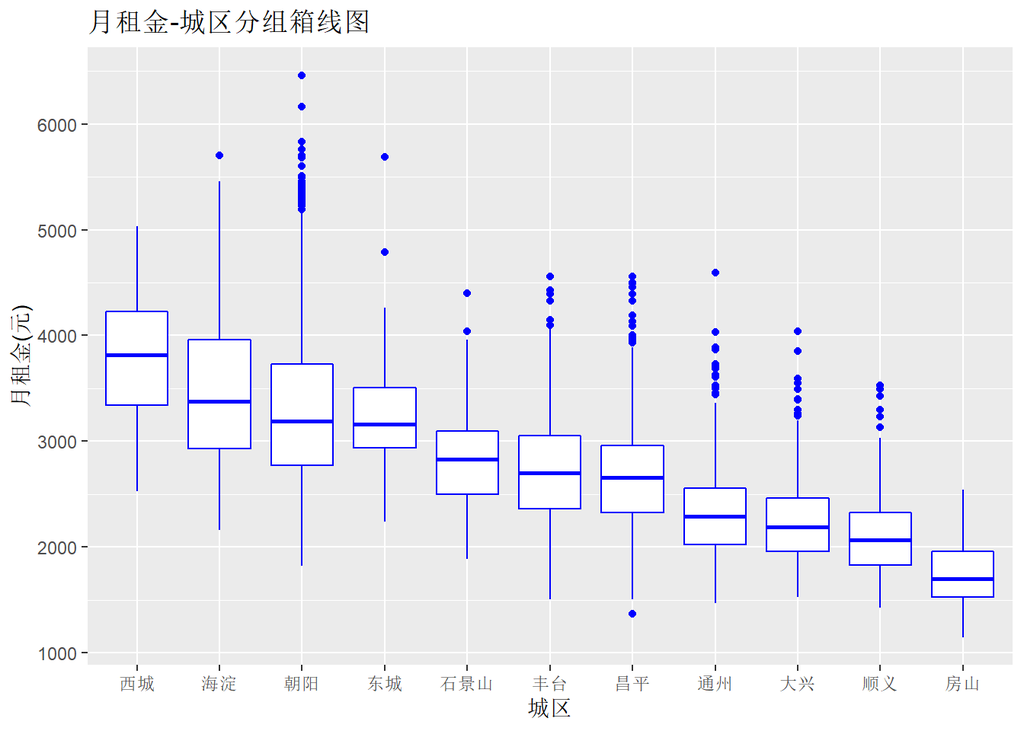

```r
library(ggplot2)
#将箱线图按中位数由高到低的顺序排序
ggplot(data, aes(x=reorder(region, -rent, median), y=rent)) + geom_boxplot(col="blue") + labs(title="月租金-城区分组箱线图",x="城区", y = "月租金(元)")
```

从图中看出，西城、海淀、朝阳城区的月租金波动范围较大，月租金整体也最高。其他城区月租金波动范围相对较小。

大体上月租金中位数越高的城区，月租金的波动范围也相对越大。

西城区月租金中位数最高，达到近4000元。房山月租金中位数最低，略高于1500元。

图中城区的异常值大部分出现在上四分位数上方，与月租金直方图右偏一致。

朝阳区异常值最多，出现在上四分位数上方。可能是因为部分地段有特殊的价值导致房价较高。

注意到各城区按月租金平均值和中位数排序相同，各城区租房的价格顺序是相对稳定的。

### 5.建立以月租金（rent）为因变量，其余为自变量的线性回归模型

建立回归模型。

定性变量的基准组为：次卧(租赁房间)、低楼层(所在楼层)、否(邻近地铁)、石景山(城区)、自采暖(供暖方式)

```r
data2 <- data
data2$room <- relevel(data2$room,'次卧')
data2$floor_grp <- relevel(data2$floor_grp,'低楼层')
data2$subway <- relevel(data2$subway,'否')
data2$region <- relevel(data2$region,'石景山')
data2$heating <- relevel(data2$heating,'自采暖')
#改变因子水平次序，使其与题目要求一致。

lin <- lm(rent~area + room + bedroom + livingroom + bathroom + heating + floor_grp + subway + region,data = data2)
summary(lin)
```

```
##
## Call:
## lm(formula = rent ~ area + room + bedroom + livingroom + bathroom +
##     heating + floor_grp + subway + region, data = data2)
##
## Residuals:
##      Min       1Q   Median       3Q      Max
## -1617.48  -275.26   -23.21   248.40  2967.39
##
## Coefficients:
##                   Estimate Std. Error t value Pr(>|t|)
## (Intercept)     1593.22405   79.93979  19.930  < 2e-16 ***
## area              76.69198    1.96317  39.065  < 2e-16 ***
## room主卧           0.08443   16.57165   0.005 0.995935
## bedroom          -90.55187    8.73965 -10.361  < 2e-16 ***
## livingroom      -168.01859   71.84304  -2.339 0.019390 *
## bathroom         182.10825   43.63344   4.174 3.05e-05 ***
## heating集中供暖  155.79086   17.13452   9.092  < 2e-16 ***
## floor_grp高楼层  -24.98532   15.95019  -1.566 0.117303
## floor_grp中楼层  -55.59610   15.29704  -3.634 0.000281 ***
## subway是         280.44440   17.73655  15.812  < 2e-16 ***
## region昌平        57.19973   34.07111   1.679 0.093245 .
## region朝阳       631.69500   31.69727  19.929  < 2e-16 ***
## region大兴      -421.98157   37.42529 -11.275  < 2e-16 ***
## region东城       565.01670   55.05629  10.263  < 2e-16 ***
## region房山      -811.82173   45.02264 -18.031  < 2e-16 ***
## region丰台       117.59678   34.57808   3.401 0.000677 ***
## region海淀       878.86347   36.51087  24.071  < 2e-16 ***
## region顺义      -450.95937   39.11271 -11.530  < 2e-16 ***
## region通州      -373.00568   32.65046 -11.424  < 2e-16 ***
## region西城       938.86226   54.33181  17.280  < 2e-16 ***
## ---
## Signif. codes:  0 '***' 0.001 '**' 0.01 '*' 0.05 '.' 0.1 ' ' 1
##
## Residual standard error: 454.1 on 5129 degrees of freedom
## Multiple R-squared:  0.6466, Adjusted R-squared:  0.6453
## F-statistic: 493.9 on 19 and 5129 DF,  p-value: < 2.2e-16
```

整理得到:

| 变量 | 回归系数 | p值 | 备注 |
| --- | --- | --- | --- |
| Intercept | 1593.2 | 2e-16 |  |
| area | 76.7 | 2e-16 |  |
| room主卧 | 0.08 | 0.996 | 基准组：次卧 |
| bedroom | -90.6 | 2e-16 |  |
| livingroom | -168.0 | 0.019 |  |
| bathroom | 182.1 | 3.05e-5 |  |
| heating集中供暖 | 155.8 | 2e-16 | 基准组：自供暖 |
| floor_grp高楼层 | -25.0 | 0.117 | 基准组：低楼层 |
| floor_grp中楼层 | -55.6 | 0.00028 | 同上 |
| subway是 | 280.4 | 2e-16 | 基准组：否 |
| region西城 | 938.9 | 2e-16 | 基准组：石景山 (以下region基准组均与此相同) |
| region海淀 | 878.9 | 2e-16 |  |
| region朝阳 | 631.7 | 2e-16 |  |
| region东城 | 565.0 | 2e-16 |  |
| region丰台 | 117.6 | 0.00068 |  |
| region昌平 | 57.2 | 0.093 |  |
| region通州 | -373.0 | 2e-16 |  |
| region大兴 | -422.0 | 2e-16 |  |
| region顺义 | -451.0 | 2e-16 |  |
| region房山 | -811.8 | 2e-16 |  |
| F检验 | p值<0.0001 | 调整的R2 | 0.6453 |

模型中回归系数表示在其他自变量一定的情况下，对应自变量增加一单位因变量的变化量；或对应自变量取值为不同类别时，相对于基准组因变量的变化量。以下对某回归系数的说明均是在其他自变量一定的情况下。

城区以石景山为基准，昌平区平均月租金比石景山高57.2元，朝阳区平均月租金比石景山高631.7元，大兴区平均月租金比石景山低422.0元。其他城区以此类推。 城区回归系数由大到小依次为：西城、海淀、朝阳、东城、丰台、昌平、石景山(基准)、通州、大兴、顺义、房山。该顺序与各城区按月租金平均值或中位数排序大致相同，不同处只有丰台、昌平两城区排在了石景山前面。通过柱状图和箱线图可以看出，这三组月租金平均值(或中位数)相近，但丰台、昌平的数据更加分散，可能是城区与面积的交互作用导致了相应回归系数的差异。

有地铁的房源平均月租金较无地铁的高约280元。集中供暖的房源平均月租金比自供暖的房源高约155.8元。有主卧的房源平均月租金较仅有次卧的房源高约0.08元。这说明有集中供暖、附近有地铁的房源更受租房者欢迎，而租房者几乎不关心房间是否有主卧。

中楼层、高楼层的房源平均月租金较低楼层的房源分别低约55.6元、25.0元。这说明租房者不太关心房源所处的楼层,相对更偏爱低层。

F统计量的p值很小，说明是显著的，至少有一个自变量对因变量有显著性影响。主卧、高楼层、昌平城区对应的p值较大，不能拒绝相应回归系数为0的原假设(显著性水平为5%下)，其与月租金的线性相关关系不显著。

其他变量对月租金的线性相关性是显著的(显著性水平为5%下)。

对该模型的回归诊断如下:

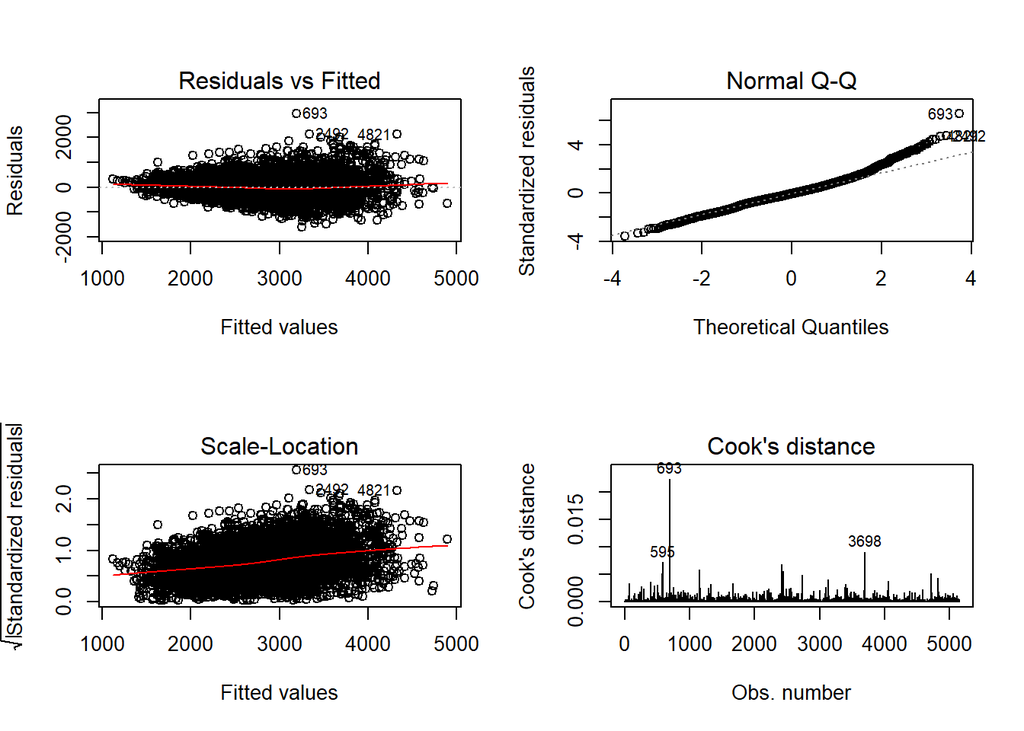

```r
par(mfrow=c(2,2))
plot(lin,which = c(1:4))
```

右上Q-Q图中，大部分点都落在图中直线上，说明残差正态性良好。在残差绝对值较大时偏离直线，说明残差偏离了正态分布。

从左上与左下图可以看出，随着拟合值的增大，残差分布范围更广，可能存在异方差现象。

右下图中，第693个点的cook距离远大于0.00078(4/5149)，是强影响点，会对模型造成较大影响。

左上图中，直线先减后增，说明模型可能有非线性问题。

### 6.对上面的回归模型利用 BIC准则进行变量选择并解读结果。

对线性回归模型利用BIC准则进行逐步回归法变量选择

```r
lin0 <- lm(rent~1,data = data2)
BIClin <- step(lin0,scope = list(lower=lin0,upper=lin),direction = "both",k = log(dim(data)[1]))
```

```
## Start:  AIC=68350.13
## rent ~ 1
##
##              Df  Sum of Sq        RSS   AIC
## + region     10 1304172375 1688238951 65488
## + area        1  589340838 2403070488 67229
## + room        1  180754650 2811656676 68038
## + subway      1  124247610 2868163716 68140
## + bedroom     1   13570927 2978840399 68335
## <none>                     2992411326 68350
## + bathroom    1    2469774 2989941552 68354
## + heating     1    1492355 2990918972 68356
## + livingroom  1     650552 2991760774 68358
## + floor_grp   2    3446982 2988964344 68361
##
## Step:  AIC=65488.34
## rent ~ region
##
##              Df  Sum of Sq        RSS   AIC
## + area        1  523987643 1164251308 63583
## + room        1  217359070 1470879881 64787
## + subway      1   67866726 1620372225 65286
## + heating     1   26866704 1661372247 65414
## + bedroom     1   22823793 1665415158 65427
## <none>                     1688238951 65488
## + bathroom    1     826935 1687412016 65494
## + livingroom  1     152830 1688086121 65496
## + floor_grp   2    1535198 1686703754 65501
## - region     10 1304172375 2992411326 68350
##
## Step:  AIC=63583.48
## rent ~ region + area
##
##              Df  Sum of Sq        RSS   AIC
## + subway      1   57464641 1106786667 63331
## + bedroom     1   30884238 1133367070 63454
## + heating     1   21850017 1142401291 63494
## <none>                     1164251308 63583
## + livingroom  1    1292416 1162958892 63586
## + room        1     837289 1163414019 63588
```

[output cut: 49 more lines]

```
##
## Step:  AIC=63140.86
## rent ~ region + area + subway + bedroom + heating + bathroom
##
##              Df  Sum of Sq        RSS   AIC
## <none>                     1061280110 63141
## + livingroom  1    1063637 1060216474 63144
## - bathroom    1    2526496 1063806606 63145
## + floor_grp   2    2680915 1058599195 63145
## + room        1       2426 1061277684 63149
## - heating     1   16883060 1078163170 63214
## - bedroom     1   23676267 1084956377 63246
## - subway      1   51936754 1113216864 63378
## - area        1  515445086 1576725197 65171
## - region     10 1216820731 2278100841 66989
```

```r
summary(BIClin)
```

```
##
## Call:
## lm(formula = rent ~ region + area + subway + bedroom + heating +
##     bathroom, data = data2)
##
## Residuals:
##      Min       1Q   Median       3Q      Max
## -1611.79  -271.91   -25.92   248.37  2980.50
##
## Coefficients:
##                 Estimate Std. Error t value Pr(>|t|)
## (Intercept)     1440.449     59.027  24.403  < 2e-16 ***
## region昌平        58.700     34.104   1.721 0.085276 .
## region朝阳       634.860     31.729  20.009  < 2e-16 ***
## region大兴      -418.866     37.422 -11.193  < 2e-16 ***
## region东城       565.767     55.124  10.264  < 2e-16 ***
## region房山      -808.478     45.011 -17.962  < 2e-16 ***
## region丰台       119.461     34.606   3.452 0.000561 ***
## region海淀       880.960     36.546  24.106  < 2e-16 ***
## region顺义      -456.412     39.038 -11.691  < 2e-16 ***
## region通州      -372.159     32.685 -11.386  < 2e-16 ***
## region西城       935.072     54.387  17.193  < 2e-16 ***
## area              76.527      1.533  49.930  < 2e-16 ***
## subway是         281.206     17.743  15.849  < 2e-16 ***
## bedroom          -91.457      8.547 -10.701  < 2e-16 ***
## heating集中供暖  154.970     17.150   9.036  < 2e-16 ***
## bathroom         141.751     40.550   3.496 0.000477 ***
## ---
## Signif. codes:  0 '***' 0.001 '**' 0.01 '*' 0.05 '.' 0.1 ' ' 1
##
## Residual standard error: 454.7 on 5133 degrees of freedom
## Multiple R-squared:  0.6453, Adjusted R-squared:  0.6443
## F-statistic: 622.7 on 15 and 5133 DF,  p-value: < 2.2e-16
```

整理后结果如下：

| 变量 | 回归系数 | p值 | 备注 |
| --- | --- | --- | --- |
| Intercept | 1440.4 | 2e-16 |  |
| area | 76.5 | 2e-16 |  |
| bathroom | 141.8 | 0.00048 |  |
| heating集中供暖 | 155.0 | 2e-16 | 基准组：自供暖 |
| subway是 | 281.2 | 2e-16 | 基准组：否 |
| bedroom | -91.5 | 2e-16 |  |
| region西城 | 935.1 | 2e-16 | 基准组：石景山 (以下region基准组均与此相同) |
| region海淀 | 881.0 | 2e-16 |  |
| region朝阳 | 634.9 | 2e-16 |  |
| region东城 | 565.8 | 2e-16 |  |
| region丰台 | 119.5 | 0.00056 |  |
| region昌平 | 58.7 | 0.085 |  |
| region通州 | -372.2 | 2e-16 |  |
| region大兴 | -418.9 | 2e-16 |  |
| region顺义 | -456.4 | 2e-16 |  |
| region房山 | -808.5 | 2e-16 |  |
| F检验 | p值<0.0001 | 调整的R2 | 0.6443 |

变量选择后得到了显著性强的解释变量，模型复杂度更低。

对模型进行回归诊断：

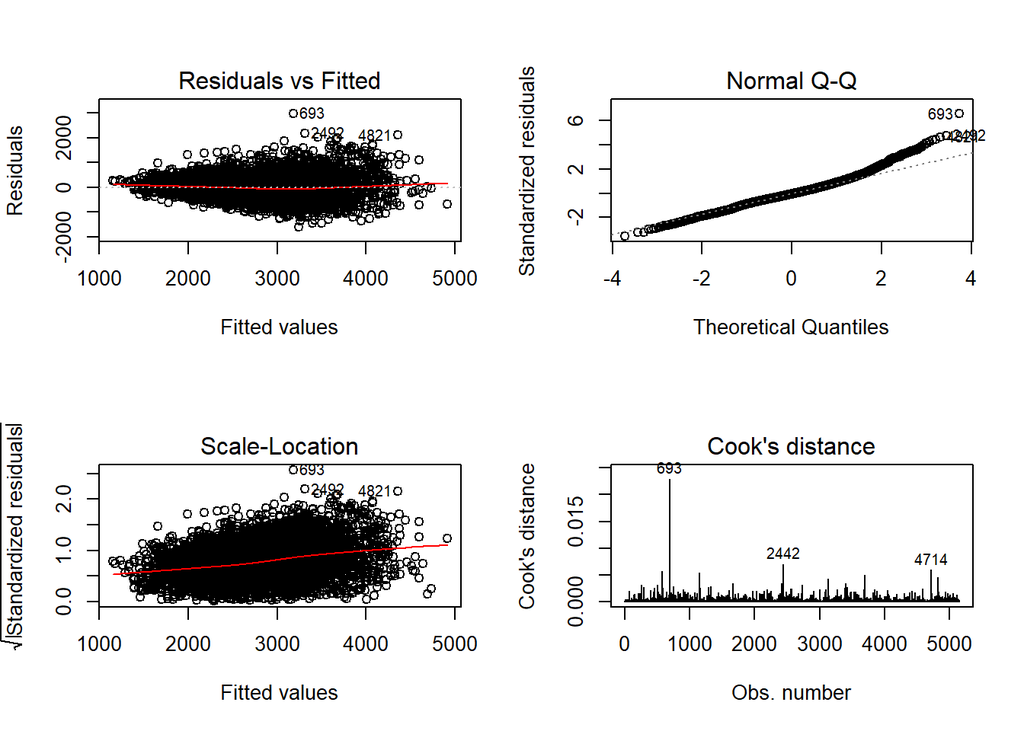

```r
par(mfrow=c(2,2))
plot(BIClin,which = c(1:4))
```

变量选择后模型的问题与前面模型中的问题相似。

右上Q-Q图中，大部分点都落在图中直线上，说明残差正态性良好。在残差绝对值较大时偏离直线，说明残差偏离了正态分布。

从左上与左下图可以看出，随着拟合值的增大，残差分布范围更广，可能存在异方差现象。

右下图中，第693个点的cook距离远大于0.00078(4/5149)，是强影响点，会对模型造成较大影响。

左上图中，直线先减后增，说明模型可能有非线性问题。

### 7.对 BIC 选择后的模型进行五折交叉验证，评估模型结果，并进行解读。

```r
#首先编写用于k折交叉验证的函数
pred.cv <- function(dat,k)
{
  ind = sample(1:k,nrow(dat),replace = T)
  pred_cv = rep(0,nrow(dat))
  for (i in 1:k)
  {
    ii = which(ind == i)
    obj = lm(rent~area + bedroom + bathroom + heating + subway + region,data = data2[-ii,])
    pred_cv[ii] = predict(obj,dat[ii,])
  }
  rmse = sqrt(mean((pred_cv - data2$rent)^2))
  return(list(pred_cv = pred_cv,rmse = rmse))
}

#进行五十次五折交叉验证
set.seed(4321)
rmses = rep(0,50)
for (i in 1:50)
{
  pred_cv = pred.cv(dat = data2,k = 5)
  rmses[i] = pred_cv$rmse
}

#计算平均均方根误差
print(mean(rmses))
```

```
## [1] 455.5204
```

五折交叉验证的平均均方根误差约为455，占租金数据的平均值(2797.5)达约16%，误差相对较大。考虑到BIC变量选择后的模型调整后的R方为0.644，说明该模型对平均月租金有一定解释能力，但仍有改进的空间。预测不够准确的原因可能是模型有异方差现象，应该对因变量进行对数或平方根的变换；也可能是模型有非线性的问题，应该对自变量进行平方、对数或平方根的变换。